**Tonight's event: Tuesday Nerd Talk (TNT):**  
Tuesday Nerd Talks is a series of informal talks on a variety of topics, given by members of the local community. Talks start at 7 pm on the first and third Tuesdays of each month and are free to attend.  
Please check our Facebook page for live music, special bottle releases, and other events or check out: **powderkegbrewingcompany.com/events**

**Upcoming talks:**  
**Mar 7:** Amy Lewis -- Global wildlife conservation  
**Mar 21:** Jeff Blumenfeld -- "Get Sponsored: A Funding Guide for Explorers, Adventurers and Would Be World Travelers”  
**Apr 4:** Roger Linfield -- Shocking science "Discoveries" that proved to be wrong  
**Apr 18:** Johnny Waldman -- TBD  
**May 9:** Ed Friedman -- Chaos & the Mandelbrot set

# Side Projects

### Devin Rourke

### Tuesday Nerd Talk @ Powder Keg Brewing Company

### February 21st, 2017

##### (a presentation written with Python + Markdown + Jupyter Notebook and displayed with reveal.js)

**side-project:** (expr.) something that you are doing aside from your main objective or job.  
*Example:* "I have a lot of side-projects going on right now. It feels like I am always in the middle of something.”  
*Example:* “In my opinion, it is very important to have side-projects. Doing something aside from my main focus helps me to relax and not take everything so seriously.”

## Famous side projects (there's a lot)

**Post-it notes:** In 1968, a scientist at 3M, Dr. Spencer Silver, was attempting to develop a super-strong adhesive. His colleague, Art Fry, used the adhesive to anchor his bookmark in his hymnbook. 11 years later, the rollout of "Post-Its" began. The original notes' yellow color was chosen by accident, as the lab next-door to the Post-It team had only yellow scrap paper to use. [[wikipedia]](https://en.wikipedia.org/wiki/Post-it_note)

[figure not shown]

**Powder Keg Brewing Company:**  
"a group of friends shared a 10 gal home-brewing kit" + "they are nerds" = good beer

[figure not shown]

**Gmail:** “I had this idea I wanted to build web-based email. I worked on it for a couple of weeks and then got bored. One of the lessons I learned from that was just in terms of my own psychology, that it was important that I always have a working product. The first thing I do on day one is build something useful, then just keep improving it.”  
-Paul Buchheit, creator and lead developer of Gmail. [[time]](http://time.com/43263/gmail-10th-anniversary/)

[figure not shown]

The 20% rule, or the 120% rule?

[figure not shown]

```python
import antigravity
```

[figure not shown]

# My side project:

## Python

## Data

## Running

# Part 1: Get Data

## Webscraping

```python
from selenium import webdriver
import html5lib, lxml
import numpy as np
import pandas as pd
import datetime
import time
import os
import matplotlib as mpl
import matplotlib.pyplot as plt
import seaborn.apionly as sns
import plotly as py
py.offline.init_notebook_mode()
```

[figure not shown]

**50** athletes / page  
**20** pages / state  
**51** states (+ DC)  
**17** years (2000 – 2016)  
**7** events (*XC*: 5000m; *Track*: 100m, 200m, 400m, 800m, 1600m, 3200m)  
**2** genders

## = 12,138,000 data points

#### Construct URL(s)

```python
state = ["AL", "AK", "AZ", "AR", "CA", "CO", "CT", "DC", "DE", "FL",
         "GA", "HI", "ID", "IL", "IN", "IA", "KS", "KY", "LA", "ME",
         "MD", "MA", "MI", "MN", "MS", "MO", "MT", "NE", "NV", "NH",
         "NJ", "NM", "NY", "NC", "ND", "OH", "OK", "OR", "PA", "RI",
         "SC", "SD", "TN", "TX", "UT", "VT", "VA", "WA", "WV", "WI", "WY"]
gender = ['Boys', 'Girls']
year = ['2000','2001','2002','2003','2004','2005','2006','2007',
        '2008','2009','2010','2011','2012','2013','2014','2015','2016']
page = ['1','2','3','4','5','6','7','8','9','10',
        '11','12','13','14','15','16','17','18','19','20']

login_url = 'https://accounts.milesplit.com/login?'
url = "http://" + state[0] + ".milesplit.com/rankings/events/" +
        "high-school-" + gender[0] + "/cross-country/5000m?year="
            + year[0] + "&page=" + page[0]

init_url = login_url + 'next=' + url
driver = webdriver.Chrome()
driver.get(init_url)
```

#### Log In

```python
username = driver.find_element_by_name("username")
password = driver.find_element_by_name("password")
username.send_keys("XXXXXX")
password.send_keys("XXXXXX")
time.sleep(3)                # explicit wait, until javascript finishes
driver.find_element_by_xpath("btn-continue").click()
time.sleep(3)
```

#### Harvest and parse the data, while looping through each URL

```python
for ge in gender:
    for st in state:
        for yr in year:
            for pg in page:
                url = "http://" + st + ".milesplit.com/rankings/events/" +
                    "high-school-" + ge + "/cross-country/5000m?year=" +
                    yr + "&page=" + pg
                driver.get(url)
                time.sleep(1)    # increase this to pretend I'm not a robot
                content = driver.page_source  # this returns the raw HTML
```

[figure not shown]

#### Find shortcuts

```python
                if "<table" not in content:
                    df_page = []
                    table_flag = 0
                    print "No results this year."
                    break
```

```python
                else:
                    table_flag = 1
                    if "pagination" not in content:
                        print "Last page of results for this year"
                        dfs.append(page_df(yr, st, ge))
                        break
```

```python
    else:
        teststring = "Page " + str(pg) + " of "
        page_of = content.find(teststring)
        num_pages = int(content[
                page_of+len(teststring):page_of+len(teststring)+2])
        if num_pages < 20:
            print "Woohoo! Shortcut.."
            pg = str(num_pages + 1)  #request page one greater than listed...
            url = "http://" + st + ".milesplit.com/rankings/events/" +
                "high-school-" + ge + "/cross-country/5000m?year=" + yr +
                "&page=" + str(pg)
            driver.get(url)
            content = driver.page_source
            time.sleep(3)
            dfs.append(page_df(yr, st, ge))
            break
            else:
                dfs.append(page_df(yr, st, ge))
                print "MOAR DATA!"
```

#### Parse HTML into a Pandas dataframe

```python
def page_df(yr, st, ge):
        df_page = pd.read_html(content)[0]
        df_page['Year'] = yr            # append Year column
        df_page['State'] = st           # append State column
        df_page['Gender'] = ge          # append Gender column
        return (df_page)
```

#### Clean up the data and export to .csv

```python
df = pd.concat(dfs, ignore_index=True)

df.columns = ['Rank', 'Time','Athlete/School','Grade','Meet',
              'Year','State','Gender']
df['Time'] = df['Time'].fillna(0).astype(str)
df['Time'] = df['Time'].str.split(':').apply(
    lambda x: int(x[0]) * 60 + float(x[1][0:4]))
df['Grade'] = df['Grade'].fillna(0).astype(int)
df['Year'] = df['Year'].fillna(0).astype(int)

df.to_csv('5K.csv', encoding='utf-8')
```

#### Read in .csv files

```python
# Read in .csv files

dfL = pd.read_csv('5K.csv')
dfR = pd.read_csv('elevation.csv', names = ['State', 'Elevation'])

df = pd.merge(dfL, dfR, on='State')

df_size = os.path.getsize('5K.csv')
print df_size
```

```
109792334
```

#### Learn about the data

```python
df.head(3)
```

|  | Rank | Time | Athlete/School | Grade | Meet | Year | State | Gender | Elevation |
| --- | --- | --- | --- | --- | --- | --- | --- | --- | --- |
| 0 | 1 | 959.9 | Tyler Stanfield Homewood HS | 2002 | Foot Locker Nationals 2001 26th Dec 8, 2001 | 2001 | AL | Boys | 500.0 |
| 1 | 2 | 1077.4 | Scott Fuqua Oak Mountain HS | 2002 | Foot Locker Nationals 2001 32nd Dec 8, 2001 | 2001 | AL | Boys | 500.0 |
| 2 | 1 | 1032.3 | Robert Bedsole Hoover | 2005 | USATF National Junior Olympic XC Championships... | 2002 | AL | Boys | 500.0 |

```python
print len(df.index)
```

```
948591
```

```python
boys = df.groupby('Gender').get_group('Boys')
girls = df.groupby('Gender').get_group('Girls')
print str(len(boys)) + ' boy records since 2000'
print str(len(girls)) + ' girl records since 2000'
```

```
526350 boy records since 2000
422241 girl records since 2000
```

```python
print df.dtypes
```

```
Rank                int64
Time              float64
Athlete/School     object
Grade               int64
Meet               object
Year                int64
State              object
Gender             object
Elevation         float64
dtype: object
```

# Part 2: Plot Stuff

# But First...

[figure not shown]

## What's your side project?

#### and when are you giving a TNT about it? (tell Adam)

# Part 2: Plot Stuff

```python
df.head(1)
```

|  | Rank | Time | Athlete/School | Grade | Meet | Year | State | Gender | Elevation |
| --- | --- | --- | --- | --- | --- | --- | --- | --- | --- |
| 0 | 1 | 959.9 | Tyler Stanfield Homewood HS | 2002 | Foot Locker Nationals 2001 26th Dec 8, 2001 | 2001 | AL | Boys | 500.0 |

```python
athlete_school = df['Athlete/School'].str.split(expand = True)
athlete_school.columns = ['First_Name' , 'Next_Name' , 'C' , 'D' , 'E' , 'F' , 'G' , 'H', 'I', 'J' , 'K']
athlete_school.head(3)
```

|  | First_Name | Next_Name | C | D | E | F | G | H | I | J | K |
| --- | --- | --- | --- | --- | --- | --- | --- | --- | --- | --- | --- |
| 0 | Tyler | Stanfield | Homewood | HS | None | None | None | None | None | None | None |
| 1 | Scott | Fuqua | Oak | Mountain | HS | None | None | None | None | None | None |
| 2 | Robert | Bedsole | Hoover | None | None | None | None | None | None | None | None |

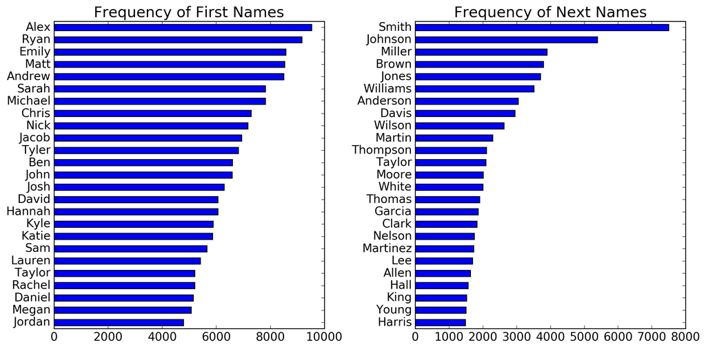

```python
plt.subplot(1, 2, 1)
athlete_school.First_Name.value_counts().head(25).plot.barh(fontsize = 14, figsize=(12,6))
ax1 = plt.gca()
ax1.invert_yaxis()
plt.title('Frequency of First Names', fontsize = 18)

plt.subplot(1, 2, 2)
athlete_school.Next_Name.value_counts().head(25).plot.barh(fontsize = 14,  figsize=(12,6))
ax2 = plt.gca()
ax2.invert_yaxis()
plt.title('Frequency of Next Names', fontsize = 18)

plt.tight_layout()
plt.show()
```

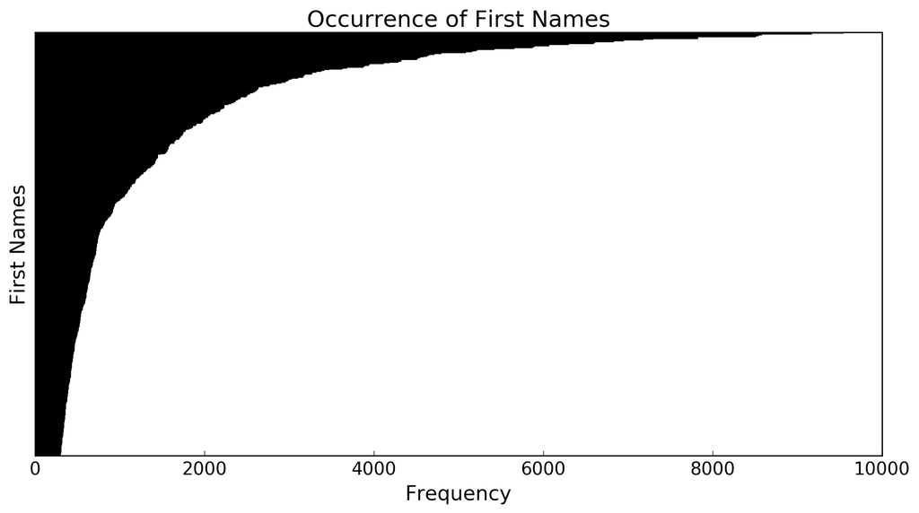

```python
plt.figure(figsize=(12,6))
athlete_school.First_Name.value_counts().head(500).plot.barh(fontsize = 14)
ax = plt.gca()
ax.invert_yaxis()
plt.yticks([])
plt.xlabel('Frequency', fontsize=16)
plt.ylabel('First Names', fontsize=16)
plt.title('Occurrence of First Names',fontsize=18)
plt.show()
```

```python
devins = sorted(athlete_school.loc[
        athlete_school['First_Name'] == 'Devin','Next_Name'].unique())
len(devins)
```

```
621
```

```python
## Fastest boys times run since 2000
boys.sort_values('Time').head(20)
```

|  | Rank | Time | Athlete/School | Grade | Meet | Year | State | Gender | Elevation |
| --- | --- | --- | --- | --- | --- | --- | --- | --- | --- |
| 418739 | 1 | 850.4 | Dathan Ritzenhein Rockford | 2001 | MHSAA State Championships LP 1st Nov 4, 2000 | 2000 | MI | Boys | 900.0 |
| 570173 | 1 | 858.7 | Edward Cheserek St. Benedict's Prep | 2013 | Essex County Championships 1st Oct 26, 2012 | 2012 | NJ | Boys | 250.0 |
| 569173 | 1 | 860.0 | Edward Cheserek St. Benedict's Prep | 2013 | Essex County Championships 1st Oct 28, 2011 | 2011 | NJ | Boys | 250.0 |
| 867606 | 1 | 860.8 | Andrew Hunter Loudoun Valley | 2016 | Third Battle Invitational 1st Oct 17, 2015 | 2015 | VA | Boys | 950.0 |
| 78805 | 1 | 864.0 | German Fernandez Riverbank High School (SJ) | 2008 | CIF State Cross Country Championships 1st Nov... | 2007 | CA | Boys | 2900.0 |
| 36452 | 1 | 867.2 | Bernie Montoya Cibola High School | 2013 | Division 1 Section 1 1st Oct 26, 2012 | 2012 | AZ | Boys | 4100.0 |
| 864589 | 1 | 868.0 | Sean McGorty Chantilly | 2013 | Foot Locker South Regional 1st Nov 24, 2012 | 2012 | VA | Boys | 950.0 |
| 888984 | 1 | 871.7 | Tanner Anderson North Central High School | 2015 | WIAA State Championship 1st Nov 8, 2014 | 2014 | WA | Boys | 1700.0 |
| 798976 | 1 | 872.2 | Brodey Hasty BrentwoodH High School | 2018 | Great American Cross Country Festival 1st Sep... | 2016 | TN | Boys | 900.0 |
| 755672 | 1 | 872.4 | David Principe Jr. La Salle Academy | 2017 | Great American Cross Country Festival 2nd Sep... | 2016 | RI | Boys | 200.0 |
| 86792 | 1 | 872.5 | Phillip Rocha Arcadia High School (SS) | 2016 | Stanford Invitational 1st Sep 26, 2015 | 2015 | CA | Boys | 2900.0 |
| 834704 | 1 | 872.5 | Conner Mantz Sky View | 2015 | Utah Region 5 XC Championships 1st Oct 16, 2013 | 2013 | UT | Boys | 6100.0 |
| 715918 | 1 | 872.7 | Matthew Maton Summit | 2015 | George Fox Cross Country Classic 1st Oct 12, ... | 2013 | OR | Boys | 3300.0 |
| 814836 | 1 | 874.0 | Craig Lutz Marcus | 2011 | Foot Locker South Regional 1st Nov 28, 2009 | 2009 | TX | Boys | 1700.0 |
| 811398 | 1 | 874.1 | Scott MacPherson Plano Senior HS | 2005 | Texas X-C State Championship 1st Nov 13, 2004 | 2004 | TX | Boys | 1700.0 |
| 270612 | 1 | 875.0 | Curtis Eckstein Oldenburg Academy | 2017 | IHSAA Cross Country Semi-State 2 - Shelbyville... | 2016 | IN | Boys | 700.0 |
| 82787 | 1 | 876.0 | Bryan Guijarro Knight High School (SS) | 2012 | Golden League Finals 1st Nov 3, 2011 | 2011 | CA | Boys | 2900.0 |
| 795976 | 1 | 876.0 | Aaron Templeton Hardin Valley Academy | 2014 | Foot Locker South Regional 1st Nov 30, 2013 | 2013 | TN | Boys | 900.0 |
| 866600 | 1 | 876.0 | Andrew Hunter Loudoun Valley | 2016 | Foot Locker South Regional 1st Nov 29, 2014 | 2014 | VA | Boys | 950.0 |
| 265611 | 1 | 876.2 | Futsum Zienasellassie North Central High Scho... | 2012 | Flashrock Invitational 1st Sep 17, 2011 | 2011 | IN | Boys | 700.0 |

```python
df.iloc[boys.Time.idxmin()]
```

```
Rank                                                          1
Time                                                      850.4
Athlete/School                      Dathan Ritzenhein  Rockford
Grade                                                      2001
Meet              MHSAA State Championships LP  1st Nov 4, 2000
Year                                                       2000
State                                                        MI
Gender                                                     Boys
Elevation                                                   900
Name: 418739, dtype: object
```

[figure not shown]

HS 2000 14:10

[figure not shown]

Colorado 2002 13:27

[figure not shown]

American Record 2009 12:56

```python
## Fastest girls times run since 2000
girls.sort_values('Time').head(20)
```

|  | Rank | Time | Athlete/School | Grade | Meet | Year | State | Gender | Elevation |
| --- | --- | --- | --- | --- | --- | --- | --- | --- | --- |
| 89606 | 1 | 984.1 | Amber Trotter Ukiah High School (NC) | 2002 | Foot Locker Nationals 2001 1st Dec 8, 2001 | 2001 | CA | Girls | 2900.0 |
| 656670 | 1 | 987.0 | Ryen Frazier Unattached (NC) | 2015 | Foot Locker South Regional 1st Nov 29, 2014 | 2014 | NC | Girls | 700.0 |
| 876766 | 1 | 989.0 | Weini Kelati Heritage (Leesburg) | 2016 | Third Battle Invitational 1st Oct 17, 2015 | 2015 | VA | Girls | 950.0 |
| 899409 | 1 | 991.1 | Amy-Eloise Neale Glacier Peak High School | 2013 | Sundodger Invitational 1st Sep 15, 2012 | 2012 | WA | Girls | 1700.0 |
| 96443 | 1 | 992.0 | Nikki Hiltz Aptos High School (CC) | 2013 | CIF California Cross Country State Meet 106th... | 2009 | CA | Girls | 2900.0 |
| 102456 | 1 | 992.1 | Fiona O'Keeffe Davis Senior High School (SJ) | 2016 | Stanford Invitational 1st Sep 26, 2015 | 2015 | CA | Girls | 2900.0 |
| 900409 | 1 | 995.0 | Alexa Efraimson Camas High School | 2015 | Bill Dellinger Invitational 1st Oct 5, 2013 | 2013 | WA | Girls | 1700.0 |
| 657671 | 1 | 996.1 | Nevada Mareno Leesville Road | 2017 | CAP 8 Conference Championship 1st Oct 20, 2015 | 2015 | NC | Girls | 700.0 |
| 28896 | 1 | 1000.0 | Allie Ostrander Kenai Central High School | 2015 | Palmer Invitational 1st Sep 6, 2014 | 2014 | AK | Girls | 1900.0 |
| 101451 | 1 | 1000.0 | Fiona O'Keeffe Davis Senior High School (SJ) | 2016 | Stanford Invitational 1st Sep 27, 2014 | 2014 | CA | Girls | 2900.0 |
| 99449 | 1 | 1000.0 | Sarah Baxter Simi Valley High (SS) | 2014 | CIF California State Cross Country Championshi... | 2012 | CA | Girls | 2900.0 |
| 827842 | 1 | 1000.5 | Devin Clark Smithson Valley | 2015 | UIL 6A - District 25 1st Oct 21, 2014 | 2014 | TX | Girls | 1700.0 |
| 626312 | 1 | 1000.9 | Aisling Cuffe Cornwall | 2011 | Great American Cross Country Festival 1st Oct... | 2010 | NY | Girls | 1000.0 |
| 48880 | 1 | 1002.9 | Danielle Jones Desert Vista High School | 2015 | Desert Twilight XC Festival 2nd Oct 3, 2014 | 2014 | AZ | Girls | 4100.0 |
| 100450 | 1 | 1003.0 | Sarah Baxter Simi Valley High (SS) | 2014 | CIF California State Cross Country Championshi... | 2013 | CA | Girls | 2900.0 |
| 128892 | 1 | 1004.0 | Brie Oakley Grandview High School | 2017 | Liberty Bell Cross Country Invitational 1st S... | 2016 | CO | Girls | 6800.0 |
| 103459 | 1 | 1005.0 | Claudia Lane Malibu High School (SS) | 2019 | CIF State Cross Country Championships 1st Nov... | 2016 | CA | Girls | 2900.0 |
| 125892 | 1 | 1005.0 | Elise Cranny Niwot High School | 2014 | Northern Conference Championship 1st Oct 5, 2013 | 2013 | CO | Girls | 6800.0 |
| 632315 | 1 | 1005.4 | Katherine Lee Shoreham-Wading River | 2018 | Brown Northeast Invitational 1st Oct 15, 2016 | 2016 | NY | Girls | 1000.0 |
| 312425 | 1 | 1005.7 | Cailie Logue Girard High School | 2017 | Baldwin Invitational 1st Oct 1, 2016 | 2016 | KS | Girls | 2000.0 |

```python
df.iloc[girls.Time.idxmin()]
```

```
Rank                                                        1
Time                                                    984.1
Athlete/School          Amber Trotter  Ukiah High School (NC)
Grade                                                    2002
Meet              Foot Locker Nationals 2001  1st Dec 8, 2001
Year                                                     2001
State                                                      CA
Gender                                                  Girls
Elevation                                                2900
Name: 89606, dtype: object
```

[figure not shown]

HS 2001 16:24

```python
df[df['Athlete/School'].str.contains('Elise Cranny')]
```

|  | Rank | Time | Athlete/School | Grade | Meet | Year | State | Gender | Elevation |
| --- | --- | --- | --- | --- | --- | --- | --- | --- | --- |
| 122922 | 32 | 1135.0 | Elise Cranny Niwot High School | 2014 | Colorado 4A Region 2 Cross Country 1st Oct 21... | 2010 | CO | Girls | 6800.0 |
| 123907 | 17 | 1114.0 | Elise Cranny Niwot High School | 2014 | St. Vrain Cross Country Invitational 1st Sep ... | 2011 | CO | Girls | 6800.0 |
| 124901 | 10 | 1073.0 | Elise Cranny Niwot High School | 2014 | Andy Myers Invitational 1st Oct 5, 2012 | 2012 | CO | Girls | 6800.0 |
| 125892 | 1 | 1005.0 | Elise Cranny Niwot High School | 2014 | Northern Conference Championship 1st Oct 5, 2013 | 2013 | CO | Girls | 6800.0 |

[figure not shown]

HS 2013 16:45

[figure not shown]

Stanford

```python
avg_5k = datetime.timedelta(seconds = df.Time.mean())
boys_avg_5k = datetime.timedelta(seconds = boys.Time.mean())
girls_avg_5k = datetime.timedelta(seconds = girls.Time.mean())

print 'Boys Average 5K:   ' +  str(boys_avg_5k)[2:7]
print 'Girls Average 5K:   ' + str(girls_avg_5k)[2:7]
print 'Average 5K:   ' + str(avg_5k)[2:7]
```

```
Boys Average 5K:   18:34
Girls Average 5K:   22:29
Average 5K:   20:18
```

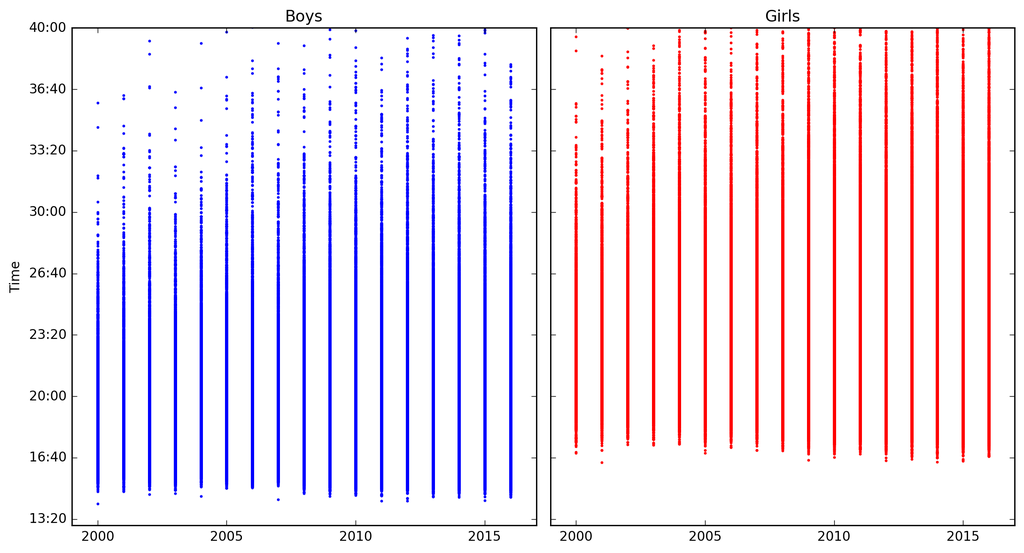

```python
f, (ax1, ax2) = plt.subplots(1, 2, sharey = True, figsize=(11, 6))
ax1.scatter(boys.Year, boys.Time, s = 5, marker = ".", color = 'b')
ax1.set_title('Boys')
ax1.set_xlim([1999, 2017])
ax1.set_ylim([13*60, 2400])
ax1.set_ylabel('Time')
ax2.scatter(girls.Year, girls.Time, s = 5, marker = ".", color = 'r')
ax2.set_title('Girls')
ax2.set_xlim([1999, 2017])
ax1.yaxis.set_major_formatter(formatter)

plt.tight_layout()
plt.show()
```

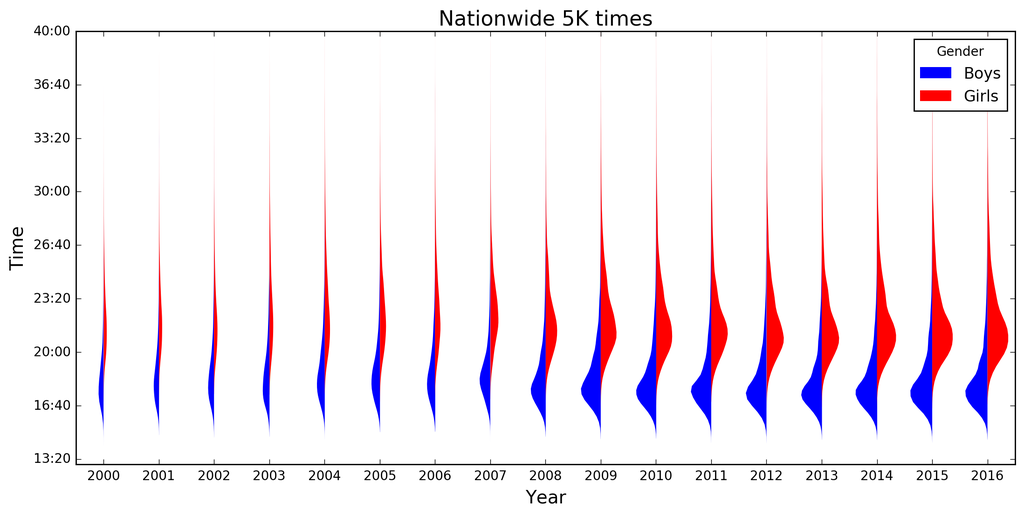

```python
fig, ax = plt.subplots(figsize=(13,6))
sns.violinplot(x=df.Year, y=df.Time, hue = df.Gender, cut = 0, scale = "count",
               scale_hue = False, inner = None, split = True, palette = {"Boys": "b", "Girls": "r"},
               bw = 'silverman', linewidth = 0, saturation = 1)
ax.yaxis.set_major_formatter(formatter)
ax.set_ylim([13*60, 2400])
plt.title('Nationwide 5K times', fontsize = 16)
plt.xlabel('Year', fontsize = 14)
plt.ylabel('Time', fontsize = 14)

plt.show()
```

# Completeness of the milesplit database

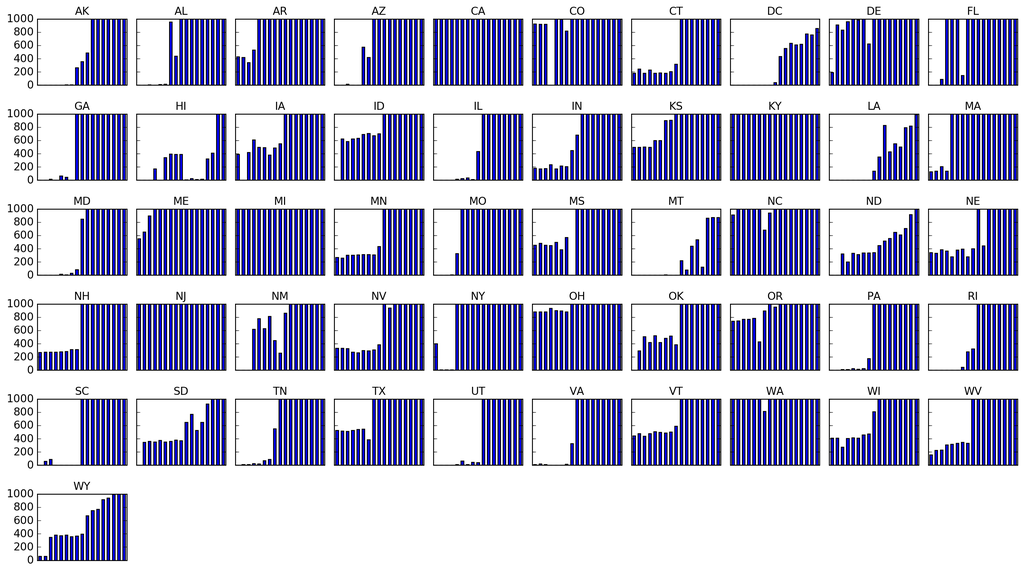

```python
years = ['2000','2001','2002','2003','2004','2005','2006','2007',
         '2008','2009','2010','2011','2012','2013','2014','2015','2016']
years = map(int, years)

ind = 0
for key in sorted(df.Time.groupby(df.State).groups.keys()):
    ind = ind + 1
    ax = plt.subplot(6, 10, ind)
    plt.axis([2000, 2016, 0, 1000])
    plt.xticks([])
    frame1 = plt.gca()
    frame1.axes.get_xaxis().set_visible(False)
    df.Time.groupby([df.State, df.Year]).count().get(key).reindex(index=years).plot.bar(
        title = key, figsize = (16, 9), fontsize = 12, sharey = True, sharex = False)
    plt.tight_layout()
    plt.xlabel('')
plt.show()
```

# Other fun stats

```python
## State Record holding Boys (only online records, only dating back to 2000)
boys.sort_values('Time').groupby('State').head(1).sort_index()
```

|  | Rank | Time | Athlete/School | Grade | Meet | Year | State | Gender | Elevation |
| --- | --- | --- | --- | --- | --- | --- | --- | --- | --- |
| 5752 | 1 | 903.3 | Mac Macoy Vestavia Hills HS | 2014 | FSU Invitational (Pre-State) 2nd Oct 11, 2013... | 2013 | AL | Boys | 500.0 |
| 22427 | 1 | 883.9 | Levi Thomet Kodiak High School | 2015 | George Fox Cross Country Classic 2nd Oct 12, ... | 2013 | AK | Boys | 1900.0 |
| 36452 | 1 | 867.2 | Bernie Montoya Cibola High School | 2013 | Division 1 Section 1 1st Oct 26, 2012 | 2012 | AZ | Boys | 4100.0 |
| 60602 | 1 | 903.0 | Jacob Shiohira Bentonville High School | 2015 | Foot Locker South Regional 13th Nov 30, 2013 | 2013 | AR | Boys | 650.0 |
| 78805 | 1 | 864.0 | German Fernandez Riverbank High School (SJ) | 2008 | CIF State Cross Country Championships 1st Nov... | 2007 | CA | Boys | 2900.0 |
| 113327 | 1 | 886.5 | Cerake Geberkidane Denver East High School | 2014 | Arvada West Cross Country Invitational 1st Se... | 2013 | CO | Boys | 6800.0 |
| 136645 | 1 | 887.0 | Alex Ostberg Darien High School | 2015 | FCIAC XC Championships 1st Oct 20, 2014 | 2014 | CT | Boys | 500.0 |
| 148550 | 1 | 916.5 | Mike Crozier Gonzaga College High School | 2012 | Nike Cross Nationals Southeast Regional 4th N... | 2011 | DC | Boys | 150.0 |
| 163089 | 1 | 906.8 | Kevin Murray Charter School of Wilmington | 2016 | Nike Cross Nationals Southeast Regional 2nd N... | 2015 | DE | Boys | 60.0 |
| 178506 | 1 | 891.0 | Matt Mizereck Leon HS | 2010 | Foot Locker South Regional 4th Nov 28, 2009 | 2009 | FL | Boys | 100.0 |
| 203462 | 1 | 881.0 | Josh Brickell Peachtree Ridge High School | 2013 | Foot Locker South Regional 4th Nov 26, 2011 | 2011 | GA | Boys | 600.0 |
| 221048 | 1 | 922.2 | Kaeo Kruse Kamehameha Schools Oahu | 2016 | Hawaii HHSAA Cross Country Championships at CO... | 2015 | HI | Boys | 3030.0 |
| 232316 | 1 | 901.0 | Elijah Armstrong Pocatello High School | 2015 | Asics Clovis Invitational 1st Oct 11, 2014 | 2014 | ID | Boys | 5000.0 |
| 247153 | 1 | 884.2 | Lukas Verzbicas Sandburg High School | 2011 | Foot Locker Midwest Regional 1st Nov 27, 2010 | 2010 | IL | Boys | 600.0 |
| 270612 | 1 | 875.0 | Curtis Eckstein Oldenburg Academy | 2017 | IHSAA Cross Country Semi-State 2 - Shelbyville... | 2016 | IN | Boys | 700.0 |
| 281009 | 1 | 884.0 | Ellen Ries North-Linn High School | 2005 | Iowa State Cross Country Meet 1st Nov 1, 2003 | 2003 | IA | Boys | 1100.0 |
| 304929 | 1 | 898.3 | Stuart Mcnutt Blue Valley West High School | 2015 | 6A Regional - Olathe Northwest 1st Oct 26, 2013 | 2013 | KS | Boys | 2000.0 |
| 323837 | 1 | 883.9 | Jacob Thomson Holy Cross (Louisville) | 2013 | Great American Cross Country Festival 2nd Sep ... | 2012 | KY | Boys | 750.0 |
| 345960 | 1 | 903.8 | Eric Coston St. Paul's School | 2017 | MC Watson Ford Invitational 1st Oct 8, 2016 | 2016 | LA | Boys | 100.0 |
| 349865 | 1 | 902.0 | Ben True Greely High School | 2004 | Foot Locker Nationals 5th Dec 13, 2003 | 2003 | ME | Boys | 600.0 |
| 380593 | 1 | 907.9 | Tyler Spear Loyola-Blakefield | 2014 | Nike Cross Nationals Southeast Regional 3rd N... | 2013 | MD | Boys | 350.0 |
| 399220 | 1 | 905.2 | John Murray Shrewsbury Senior High School | 2011 | Brown Invitational 2nd Oct 16, 2010 | 2010 | MA | Boys | 500.0 |
| 418739 | 1 | 850.4 | Dathan Ritzenhein Rockford | 2001 | MHSAA State Championships LP 1st Nov 4, 2000 | 2000 | MI | Boys | 900.0 |
| 461397 | 1 | 894.1 | Seth Eliason Hopkins High School | 2017 | Nike Cross Nationals Heartland Regional 4th N... | 2016 | MN | Boys | 1200.0 |
| 471601 | 1 | 919.2 | Max Holman Tupelo High School | 2010 | Trinity/Valkyrie Invitational 4th Sep 18, 200... | 2009 | MS | Boys | 300.0 |
| 488396 | 1 | 900.6 | Caleb Hoover College Heights Christian | 2011 | Missouri Southern Stampede 1st Sep 18, 2010 | 2010 | MO | Boys | 800.0 |
| 508744 | 1 | 904.4 | Marshall Beatty Sentinel High School | 2017 | Missoula Coaches Meet 1st Sep 1, 2016 | 2016 | MT | Boys | 3400.0 |
| 520628 | 1 | 879.5 | Seth Hirsch Millard West High School | 2017 | Nike Cross Nationals Heartland Regional 2nd N... | 2016 | NE | Boys | 2600.0 |
| 533020 | 1 | 899.7 | Henry Weisberg McQueen High School | 2017 | Stanford Invitational 4th Oct 1, 2016 | 2016 | NV | Boys | 5500.0 |
| 549475 | 1 | 903.4 | Patrick O'brien Oyster River High School | 2017 | NH Meet of Champions 1st Nov 5, 2016 | 2016 | NH | Boys | 1000.0 |
| 570173 | 1 | 858.7 | Edward Cheserek St. Benedict's Prep | 2013 | Essex County Championships 1st Oct 26, 2012 | 2012 | NJ | Boys | 250.0 |
| 594997 | 1 | 894.4 | Luis Martinez Sue Cleveland High School | 2013 | Nike Cross Regionals - Southwest 3rd Nov 17, ... | 2012 | NM | Boys | 5700.0 |
| 617832 | 1 | 887.0 | Jeriqho Gadway Plattsburgh HS | 2015 | Section 7 Championships 1st Oct 31, 2014 | 2014 | NY | Boys | 1000.0 |
| 642538 | 1 | 884.0 | Ben Huffman Providence Day School | 2014 | Foot Locker South Regional 2nd Nov 30, 2013 | 2013 | NC | Boys | 700.0 |
| 663319 | 1 | 896.0 | Jake Leingang Bismarck High School | 2013 | Foot Locker Midwest Regional 1st Nov 24, 2012 | 2012 | ND | Boys | 1900.0 |
| 678380 | 1 | 884.7 | Andrew Jordan Watkins Memorial | 2016 | Galion Cross Country Festival 1st Sep 19, 2015 | 2015 | OH | Boys | 850.0 |
| 700649 | 1 | 891.0 | Ben Barrett Norman North High School | 2015 | Foot Locker South Regional 6th Nov 30, 2013 | 2013 | OK | Boys | 1300.0 |
| 715918 | 1 | 872.7 | Matthew Maton Summit | 2015 | George Fox Cross Country Classic 1st Oct 12, ... | 2013 | OR | Boys | 3300.0 |
| 739802 | 1 | 887.0 | Noah Affolder Carlisle | 2017 | 24th Carlisle High School Invitational 1st Se... | 2016 | PA | Boys | 1100.0 |
| 755672 | 1 | 872.4 | David Principe Jr. La Salle Academy | 2017 | Great American Cross Country Festival 2nd Sep... | 2016 | RI | Boys | 200.0 |
| 766366 | 1 | 886.8 | Brent Demarest Porter Gaud | 2014 | SCISA Championships 1st Oct 26, 2013 | 2013 | SC | Boys | 350.0 |
| 787577 | 1 | 897.1 | Derick Peters West Central High School | 2018 | Lennox Invitational 1st Sep 30, 2016 | 2016 | SD | Boys | 2200.0 |
| 798976 | 1 | 872.2 | Brodey Hasty BrentwoodH High School | 2018 | Great American Cross Country Festival 1st Sep... | 2016 | TN | Boys | 900.0 |
| 814836 | 1 | 874.0 | Craig Lutz Marcus | 2011 | Foot Locker South Regional 1st Nov 28, 2009 | 2009 | TX | Boys | 1700.0 |
| 834704 | 1 | 872.5 | Conner Mantz Sky View | 2015 | Utah Region 5 XC Championships 1st Oct 16, 2013 | 2013 | UT | Boys | 6100.0 |
| 853024 | 1 | 924.2 | Tyler Marshall Champlain Valley Union High Sc... | 2017 | NVAC Championship 1st Oct 29, 2016 | 2016 | VT | Boys | 1000.0 |
| 867606 | 1 | 860.8 | Andrew Hunter Loudoun Valley | 2016 | Third Battle Invitational 1st Oct 17, 2015 | 2015 | VA | Boys | 950.0 |
| 888984 | 1 | 871.7 | Tanner Anderson North Central High School | 2015 | WIAA State Championship 1st Nov 8, 2014 | 2014 | WA | Boys | 1700.0 |
| 908753 | 1 | 898.0 | Jacob Burcham Cabell Midland | 2013 | West Virginia State XC Championships 1st Oct ... | 2012 | WV | Boys | 1500.0 |
| 931718 | 1 | 879.4 | Finn Gessner Madison La Follette | 2017 | Nike Cross Nationals Heartland Regional 1st N... | 2016 | WI | Boys | 1050.0 |
| 943190 | 1 | 917.5 | Brody Smith Cody High School | 2016 | Nike Portland XC Invite 3rd Sep 26, 2015 | 2015 | WY | Boys | 6700.0 |

```python
## State Record holding Girls (only online records, only dating back to 2000)
girls.sort_values('Time').groupby('State').head(1).sort_index()
```

|  | Rank | Time | Athlete/School | Grade | Meet | Year | State | Gender | Elevation |
| --- | --- | --- | --- | --- | --- | --- | --- | --- | --- |
| 16438 | 1 | 1017.0 | Amaris Tyynismaa Catholic - Montgomery | 2019 | Foot Locker South Regional 1st Nov 29, 2014 | 2014 | AL | Girls | 500.0 |
| 28896 | 1 | 1000.0 | Allie Ostrander Kenai Central High School | 2015 | Palmer Invitational 1st Sep 6, 2014 | 2014 | AK | Girls | 1900.0 |
| 48880 | 1 | 1002.9 | Danielle Jones Desert Vista High School | 2015 | Desert Twilight XC Festival 2nd Oct 3, 2014 | 2014 | AZ | Girls | 4100.0 |
| 68268 | 1 | 1054.0 | Maggie Montoya Rogers High School | 2013 | Arkansas Chili Pepper Festival Invitational 1... | 2011 | AR | Girls | 650.0 |
| 89606 | 1 | 984.1 | Amber Trotter Ukiah High School (NC) | 2002 | Foot Locker Nationals 2001 1st Dec 8, 2001 | 2001 | CA | Girls | 2900.0 |
| 128892 | 1 | 1004.0 | Brie Oakley Grandview High School | 2017 | Liberty Bell Cross Country Invitational 1st S... | 2016 | CO | Girls | 6800.0 |
| 143838 | 1 | 1035.8 | Hannah Debalsi Staples High School | 2016 | New England XC Championship 1st Nov 9, 2013 | 2013 | CT | Girls | 500.0 |
| 151928 | 1 | 1042.0 | Devoe Arnold St. Albans School | 2014 | IAC, ISL, MAC Championships 5th Oct 26, 2013 | 2013 | DC | Girls | 150.0 |
| 169272 | 1 | 1013.0 | Julie Macedo Charter School of Wilmington | 2012 | Six Flags Wild Safari Invitational - Girls 1s... | 2011 | DE | Girls | 60.0 |
| 192393 | 1 | 1014.1 | Kathryn Fluehr Community School of Naples | 2011 | FHSAA 1A District 6 1st Nov 4, 2010 | 2010 | FL | Girls | 100.0 |
| 213533 | 1 | 1028.0 | Grace Tinkey First Presbyterian Day School | 2013 | Foot Locker South Regional 3rd Nov 26, 2011 | 2011 | GA | Girls | 600.0 |
| 222559 | 1 | 1091.4 | Lauren Ho Hawaii Baptist Academy | 2006 | Hawaii State Cross Country Championships 1st ... | 2005 | HI | Girls | 3030.0 |
| 243795 | 1 | 1034.0 | Alexa White Soda Springs High School | 2017 | Idaho State Cross Country Championships 4th O... | 2015 | ID | Girls | 5000.0 |
| 258691 | 1 | 1019.5 | Anna Sophia Keller St. Anthony High School | 2017 | Shelbyville Trail Invitational 1st Sep 13, 2014 | 2014 | IL | Girls | 600.0 |
| 276199 | 1 | 1012.2 | Anna Rohrer Mishawaka High School | 2015 | Viking Stampede 1st Aug 24, 2013 | 2013 | IN | Girls | 700.0 |
| 292521 | 1 | 1017.0 | Stephanie Jenks Linn-Mar High School | 2016 | Bill Dellinger Invitational 7th Oct 5, 2013 | 2013 | IA | Girls | 1100.0 |
| 312425 | 1 | 1005.7 | Cailie Logue Girard High School | 2017 | Baldwin Invitational 1st Oct 1, 2016 | 2016 | KS | Girls | 2000.0 |
| 340310 | 1 | 1013.0 | Gabby Karas Martha Layne Collins | 2017 | Foot Locker South Regional 3rd Nov 29, 2014 | 2014 | KY | Girls | 750.0 |
| 346633 | 1 | 1068.2 | Malia Cali St. Thomas Aquinas | 2010 | Mobile Cross Country Challenge of Champions 20... | 2009 | LA | Girls | 100.0 |
| 370050 | 1 | 1055.3 | Abbey Leonardi Kennebunk High School | 2012 | Foot Locker Nationals 4th Dec 9, 2011 - Dec 1... | 2011 | ME | Girls | 600.0 |
| 392012 | 1 | 1034.0 | Abigail Green Walter Johnson High School | 2018 | Pacers Running DCXC Invite presented by New Ba... | 2016 | MD | Girls | 350.0 |
| 406269 | 1 | 1025.1 | Natasha Roetter Lexington High School | 2002 | Foot Locker Nationals 2001 3rd Dec 8, 2001 | 2001 | MA | Girls | 500.0 |
| 443585 | 1 | 1014.8 | Megan Goethals Rochester | 2010 | MHSAA State Championships LP 1st Nov 7, 2009 | 2009 | MI | Girls | 900.0 |
| 466305 | 1 | 1020.4 | Anna Fenske Farmington High School | 2021 | Nike Cross Nationals Heartland Regional 3rd N... | 2016 | MN | Girls | 1200.0 |
| 480058 | 1 | 1077.0 | Abbey Dixon West Memphis Christian School | 2012 | Foot Locker South Regional 26th Nov 26, 2011 | 2011 | MS | Girls | 300.0 |
| 502991 | 1 | 1007.2 | Taylor Werner Ste. Genevieve High School | 2016 | Forest Park XC Festival 1st Sep 14, 2013 | 2013 | MO | Girls | 800.0 |
| 510625 | 1 | 1042.2 | Annie Hill Glacier High School | 2018 | Nike Cross Nationals Northwest Regional 1st N... | 2016 | MT | Girls | 3400.0 |
| 525254 | 1 | 1081.6 | Taylor Somers Millard South High School | 2017 | Nike Cross Nationals Heartland Regional 18th ... | 2016 | NE | Girls | 2600.0 |
| 534719 | 1 | 1039.0 | Marie Lawrence Reno High School | 2007 | Foot Locker Nationals 2nd Dec 10, 2005 | 2005 | NV | Girls | 5500.0 |
| 557855 | 1 | 1032.5 | Jacqueline Gaughan Exeter High School | 2018 | Brown Northeast Invitational 2nd Oct 15, 2016 | 2016 | NH | Girls | 1000.0 |
| 587258 | 1 | 1017.0 | Briana Gess Haddonfield Mem. HS | 2017 | Colonial Conf. All Star Meet 1st Oct 24, 2013 | 2013 | NJ | Girls | 250.0 |
| 606300 | 1 | 1049.0 | Amanda Mayoral Sue Cleveland High School | 2018 | Nike Cross Nationals Southwest Regional 3rd N... | 2015 | NM | Girls | 5700.0 |
| 626312 | 1 | 1000.9 | Aisling Cuffe Cornwall | 2011 | Great American Cross Country Festival 1st Oct... | 2010 | NY | Girls | 1000.0 |
| 656670 | 1 | 987.0 | Ryen Frazier Unattached (NC) | 2015 | Foot Locker South Regional 1st Nov 29, 2014 | 2014 | NC | Girls | 700.0 |
| 666973 | 1 | 1033.2 | Karly Ackley Grand Forks Central High School | 2017 | North Dakota State Cross Country Championships... | 2016 | ND | Girls | 1900.0 |
| 692094 | 1 | 1027.5 | India Johnson Hilliard Davidson | 2017 | Nike Cross Nationals Midwest Regional 2nd Nov... | 2016 | OH | Girls | 850.0 |
| 704925 | 1 | 1031.0 | Alex Davis Plainview High School | 2013 | Foot Locker South Regional 4th Nov 24, 2012 | 2012 | OK | Girls | 1300.0 |
| 729630 | 1 | 1006.6 | Ella Donaghu Grant | 2016 | Sundodger Invitational 1st Sep 19, 2015 | 2015 | OR | Girls | 3300.0 |
| 748942 | 1 | 1032.0 | Aislinn Devlin Downingtown West | 2017 | PIAA District 1 Championships 1st Oct 28, 2016 | 2016 | PA | Girls | 1100.0 |
| 760194 | 1 | 1049.2 | Ellie Lawler South Kingstown High School | 2018 | Rhode Island State Championships 1st Nov 8, 2015 | 2015 | RI | Girls | 200.0 |
| 776444 | 1 | 1038.0 | Logan Morris Spartanburg Christian | 2016 | Foot Locker South Regional 9th Nov 29, 2014 | 2014 | SC | Girls | 350.0 |
| 788579 | 1 | 1045.0 | Ramsey Kavan Yankton High School | 2005 | Foot Locker Midwest Regional 1st Nov 27, 2004 | 2004 | SD | Girls | 2200.0 |
| 807318 | 1 | 1017.4 | Rebecca Story Christian Academy of Knoxville | 2018 | 17th Annual Jesse Owens Classic 1st Oct 3, 2015 | 2015 | TN | Girls | 900.0 |
| 827842 | 1 | 1000.5 | Devin Clark Smithson Valley | 2015 | UIL 6A - District 25 1st Oct 21, 2014 | 2014 | TX | Girls | 1700.0 |
| 842207 | 1 | 1020.6 | Sarah Feeny Ogden | 2014 | Utah Region 5 XC Championships 1st Oct 16, 2013 | 2013 | UT | Girls | 6100.0 |
| 858100 | 1 | 1068.3 | Autumn Eastman Champlain Valley Union High Sc... | 2014 | New England XC Championship 3rd Nov 9, 2013 | 2013 | VT | Girls | 1000.0 |
| 876766 | 1 | 989.0 | Weini Kelati Heritage (Leesburg) | 2016 | Third Battle Invitational 1st Oct 17, 2015 | 2015 | VA | Girls | 950.0 |
| 899409 | 1 | 991.1 | Amy-Eloise Neale Glacier Peak High School | 2013 | Sundodger Invitational 1st Sep 15, 2012 | 2012 | WA | Girls | 1700.0 |
| 917677 | 1 | 1024.0 | Amelia Paladino University High | 2014 | Foot Locker South Regional 2nd Nov 30, 2013 | 2013 | WV | Girls | 1500.0 |
| 933419 | 1 | 1028.0 | Molly Seidel University Lake School | 2012 | Foot Locker Midwest Regional 1st Nov 26, 2011 | 2011 | WI | Girls | 1050.0 |
| 948147 | 1 | 1051.0 | Anna Gibson Jackson Hole High School | 2017 | Liberty Bell Cross Country Invitational 3rd S... | 2016 | WY | Girls | 6700.0 |

# Nationwide Trends

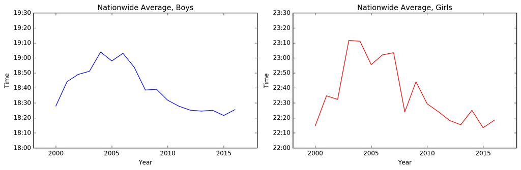

```python
plt.subplot(1,2,1)
boys.Time.groupby(df.Year).mean().plot(color = 'b', figsize=(12,4))
plt.axis([1998, 2018, 18*60, 19.5*60])
plt.ylabel('Time')
plt.title('Nationwide Average, Boys')
ax1 = plt.gca()
ax1.yaxis.set_major_formatter(formatter)

plt.subplot(1,2,2)
girls.Time.groupby(df.Year).mean().plot(color = 'r', figsize=(12,4))
plt.axis([1998, 2018, 22*60, 23.5*60])
plt.ylabel('Time')
plt.title('Nationwide Average, Girls')
ax2 = plt.gca()
ax2.yaxis.set_major_formatter(formatter)

plt.tight_layout()
plt.show()
```

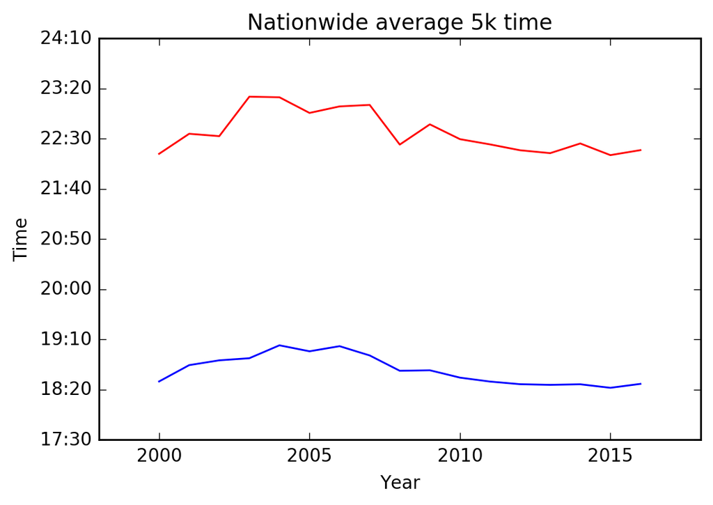

```python
boys.Time.groupby(df.Year).mean().plot(color = 'b')
girls.Time.groupby(df.Year).mean().plot(color = 'r')
plt.axis([1998, 2018, 1050, 1450])
plt.ylabel('Time')
plt.title('Nationwide average 5k time')
ax = plt.gca()
ax.yaxis.set_major_formatter(formatter)
plt.show()
```

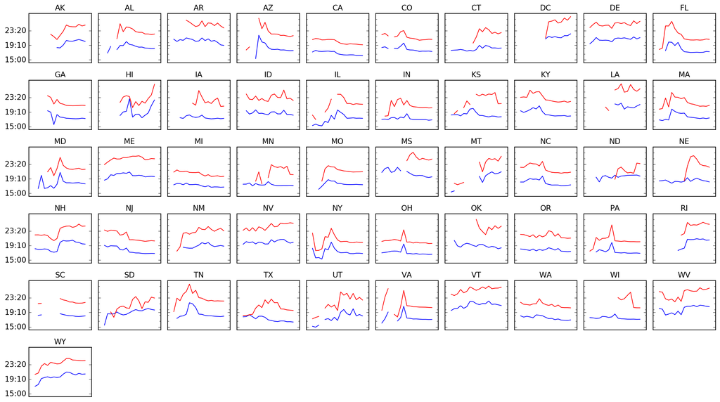

```python
df2 = boys.Time.groupby([df.State, df.Year]).mean()
df3 = girls.Time.groupby([df.State, df.Year]).mean()
years = ['2000','2001','2002','2003','2004','2005','2006','2007',
         '2008','2009','2010','2011','2012','2013','2014','2015','2016']
years = map(int, years)
ind = 0
for key in sorted(df.Time.groupby(df.State).groups.keys()):
    ind = ind + 1
    plt.subplot(6, 10, ind)
    plt.xticks([])
    frame1 = plt.gca()
    frame1.axes.get_xaxis().set_visible(False)
    df2[key].fillna(0).reindex(index = years).plot(title = key, figsize = (16, 9), yticks = [900, 1150, 1400],
                            color = 'b', fontsize = 12, sharey = True, sharex = False)
    df3[key].fillna(0).reindex(index = years).plot(title = key, figsize = (16, 9), yticks = [900, 1150, 1400],
                            color = 'r', fontsize = 12, sharey = True, sharex = False)
    plt.axis([1998, 2018, 850, 1700])
    ax = plt.gca()
    ax.yaxis.set_major_formatter(formatter)
    plt.tight_layout()
    plt.xlabel('')
plt.show()
```

```python
for col in dfR.columns:
    df[col] = df[col].astype(str)

scl = [[0.0, 'rgb(242,240,247)'],[0.2, 'rgb(218,218,235)'],[0.4, 'rgb(188,189,220)'],
       [0.6, 'rgb(158,154,200)'],[0.8, 'rgb(117,107,177)'],[1.0, 'rgb(84,39,143)']]

# scl = [[0.0, '#edf8e9'],[0.2, '#c7e9c0'],[0.4, '#a1d99b'],
#        [0.6, '#74c476'],[0.8, '#31a354'],[1.0, '#006d2c']]

# df['text'] = df['state'] + '<br>' +\
#     '2000 '+df['2000']+' 2001 '+df['2001']+'<br>'+\
#     '2002 '+df['2002']+' 2003 ' + df['2003']+'<br>'+\
#     '2004 '+df['2004']+' 2005 '+df['2005']

data = [dict(
        type='choropleth',
        colorscale = scl,
        autocolorscale = False,
        locations = dfR['State'],
        z = dfR['Elevation'].astype(float),
        locationmode = 'USA-states',
        marker = dict(
            line = dict(
                    color = 'rgb(255,255,255)',
                    width = 1)),
            colorbar = dict(
                    title = "Elevation (ft)"))]

layout = dict(
            title = 'US Elevation by State<br>(Hover for detail)',
            geo = dict(
                scope='usa',
                projection=dict(type = 'albers usa'),
                showlakes = False,
                lakecolor = 'rgb(255, 255, 255)'),)

fig = dict(data = data, layout = layout)
py.offline.iplot(fig, filename = 'plotly-elevation')
```

[interactive chart not shown]

```python
year = ['2000','2001','2002','2003','2004','2005','2006','2007',
        '2008','2009','2010','2011','2012','2013','2014','2015','2016']

# year = ['2000']

dfplotly = pd.read_csv('d3usa5kboys.csv')

scl = [[0.0, '#a80000'],[0.25, '#ff3f3f'],[0.5, '#ff7f7f'],
       [0.75, '#ffbfbf'],[1.0, '#ffffff']]

for yr in year:

    # df['text'] = df['state'] + '<br>' +\
    #     '2000 '+df['2000']+' 2001 '+df['2001']+'<br>'+\
    #     '2002 '+df['2002']+' 2003 ' + df['2003']+'<br>'+\
    #     '2004 '+df['2004']+' 2005 '+df['2005']

    data = [ dict(
        type='choropleth',
        colorscale = scl,
        autocolorscale = False,
        locations = dfplotly['code'],
        z = dfplotly[yr].astype(float),
        zmax = 20.0,
        zmin = -20.0,
        zauto = False,
        locationmode = 'USA-states',
        marker = dict(
            line = dict (
                color = 'rgb(255,255,255)',
                width = 1
            ) ),
            colorbar = dict(
            title = "% Difference"
        ))]

    layout = dict(
        title = 'Percent difference from yearly national average<br>Boys 5K<br><br>'+yr,
        geo = dict(
            scope='usa',
            projection=dict( type='albers usa'),
            showlakes = False))

    fig = dict(data=data, layout=layout)
    py.offline.iplot(fig, filename='choropleth-map_' + yr, image_height = 600, image_width = 900,  image = 'png')
#     py.offline.iplot(fig, filename='choropleth-map_' + yr, image_height = 1200, image_width = 1600)
```

[figure not shown]

# Closer to home..

[figure not shown]

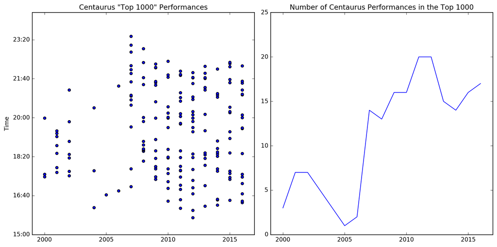

```python
dfCHS = df[df['Athlete/School'].str.contains("Centaurus High School")]
f, (ax1, ax2) = plt.subplots(1, 2, figsize=(12, 6))

ax1.scatter(dfCHS.Year, dfCHS.Time)
ax1.set_title('Centaurus "Top 1000" Performances')
ax1.set_xlim([1999, 2017])
ax1.set_ylim([15*60, 24.5*60])
ax1.set_ylabel('Time')
ax1.yaxis.set_major_formatter(formatter)

ax2.plot(dfCHS.Year.unique(), dfCHS.groupby('Year').Time.nunique())
ax2.set_title('Number of Centaurus Performances in the Top 1000')
ax2.set_xlim([1999, 2017])
ax2.set_ylim([0, 25])

plt.tight_layout()
plt.show()
```

# To Do

- get "Year = All" records
- Integrate "course difficulty" ratings
- Track
- Determine seconds / ft conversion
- Machine Learning, feature selection.. predict times?

[figure not shown]

## Thanks!

devin.rourke@gmail.com

devinrourke.github.io